# MALT Assignement Results Summary

# Introduction

This notebook is to generate a variety of summary statistics for the alignment of non-human reads to various database with the highthroughput aligner MALT.

# Infrastructure

Load tidyverse for data wrangling and plotting

```r
library(tidyverse)
library(ggbeeswarm)
library(scales)
library(patchwork)
library(dabestr)
```

Set project directory (if required!)

```r
proj_dir <- "../"
```

Load files to be analysed - fortunately nt stats are already in metadata.

> Important: the NT file had to be manually modified after generation, due to log files containing duplicate log entries of broken FASTQ files or issues when we had HDD space limitations, so were re-run. These duplicates/broken entries were therefore deleted.

```r
metadata <- read_tsv(paste0(proj_dir, "00-documentation.backup/02-calculus_microbiome-deep_evolution-individualscontrolssources_metadata_20190523.tsv"))
data_refseq_raw <- read_tsv(paste0(proj_dir, "00-documentation.backup/05-MALT_taxonomic_binning_summary_statistics_refseq_bacarchhomo_gcs_20181122_20190410.tsv"))
```

We will also load a MEGAN table for nt at domain level to look at bacterial/archaeal/viral vs eukaryotic content.

```r
data_megan_nt_domain <- read_tsv(paste0(proj_dir, "04-analysis/screening/megan.backup/Evolution-Comparison_MEGAN_20190703-ex_absolute_domain_all_summarised_nt.txt"))
```

# Data Wrangling

## Refseq stats

Clean up refseq MALT run statistics

```r
strings_to_remove <- paste("_S0_L000_R1_000.fastq.merged.prefixed.hg19unmapped.rma6",
                           "_S0_L001_R1_000.fastq.merged.prefixed.hg19unmapped.rma6",
                           "_S0_L001_R1_001.fastq.combined.fq.prefixed.extractunmapped.bam.rma6",
                           "_S0_L003_R1_001.sorted.bam.unmapped.rma6",
                           "_S0_L000_R1_000.fastq.merged.rma6",
                           "_S0_L003_R1_001.fastq.combined.fq.prefixed.extractunmapped.bam.rma6",
                            sep = "|")

data_refseq_clean <- data_refseq_raw %>% mutate(Sample = map(File,
                                    ~ gsub(strings_to_remove,
                                           "",
                                           .x)) %>%
                         unlist) %>%
  select(Sample, everything(), -File)

## During re-contatenation for refseq, accidently performed an incorrect file
## `rename` so lost extrac/library info from name. We can fix this here:

list_namefixes_A <- c("ABM007", "ABM008", "BIT001", "CDC005", "CDC011", "DJA006", "DJA007",
  "EBO008", "EBO009", "FDM001", "GDN001", "IBA001",
  "IBA002", "LOB001", "MOA001", "MTK001", "MTM003", "MTM010", "MTM011",
  "MTM012", "MTM013", "MTS001", "MTS002", "MTS003", "TAF017", "TAF018",
  "WAL001")

list_namefixes_B <- c("ECO002", "ECO004")

data_refseq_clean <- data_refseq_clean %>% mutate(Sample = case_when(Sample %in% list_namefixes_A ~ paste0(Sample, ".A0101"),
                                                Sample %in% list_namefixes_B ~ paste0(Sample, ".B0101") ,
                                                TRUE ~ Sample)) %>%
  rename_all(function(x) paste0("RefSeq_", x)) %>%
  rename(Sample = RefSeq_Sample)

## Join with metadata, removing an accidently included UDG treated lib blank
data_refseq_clean <- data_refseq_clean %>%
  filter(Sample != "LIB025.A0301") %>%
  left_join(metadata, by = c("Sample" = "#SampleID"))
```

## Domain level stats

Clean up domain level nt table

```r
data_megan_nt_domain_ratios <- data_megan_nt_domain %>%
  gather(Sample, Alignments, 2:ncol(.)) %>%
  filter(!grepl("LIB025.A0301", Sample)) %>%
  mutate(Sample = map(Sample, ~ gsub(strings_to_remove %>% gsub(".rma6", "", .), "", .x)) %>%
                         unlist) %>%
  rename(Domain = `#Datasets`) %>%
  spread(Domain, Alignments) %>%
  group_by(Sample) %>%
  summarise(NonEukaryotic_Total = Archaea + Bacteria + Viruses,
            Eukaryota = Eukaryota) %>%
  mutate(Ratio = (NonEukaryotic_Total / Eukaryota)) %>%
  left_join(metadata, by = c("Sample" = "#SampleID")) %>%
  print()
```

| Sample | NonEukaryotic_Total | Eukaryota | Ratio | BarcodeSequence | LinkerPrimerSequence | Study | Accession_ID | SourceSink | Env | Description | Host_General | Host_Genus | Host_Common | Code | Is_Oral | Age | Location | Site | ToothSource | Type | LabProtocol | ScreeningDeepData | NCBI Project ID | individual_id | SumSampleWeight_mg | SumExtractionConcentration_ng_ul | SumLibraryConcentration_copies_ul | Sample_or_Control | Individual_Seq_Depth | … |
| --- | --- | --- | --- | --- | --- | --- | --- | --- | --- | --- | --- | --- | --- | --- | --- | --- | --- | --- | --- | --- | --- | --- | --- | --- | --- | --- | --- | --- | --- | --- |
| ABM006.A0101 | 1888822 | 25298 | 7.466290e+01 | NA | NA | This_study | NA | sink | Gorilla_2 | Gorilla_gorilla_gorilla | Gorilla | Gorilla | Gorilla | GO2 | Calculus | Historical | Cameroon | Abong Mbong | Molar | Calculus | B.3 | Screening | NA | ABM006 | 0.0 | 0.444000 | 15730000 | Sample | 8124616 | … |
| ABM007.A0101 | 1973932 | 12083 | 1.633644e+02 | NA | NA | This_study | NA | sink | Chimp_3 | Pan_troglodytes | Chimp | Pan | Pan | PA3 | Calculus | Historical | Cameroon | Abong Mbong | Molar | Calculus | B.3 | Screening | NA | ABM007 | 0.0 | 0.119000 | 54580000 | Sample | 13036934 | … |
| ABM008.A0101 | 751588 | 6057 | 1.240859e+02 | NA | NA | This_study | NA | sink | Chimp_3 | Pan_troglodytes | Chimp | Pan | Pan | PA3 | Calculus | Historical | Cameroon | Abong Mbong | Molar | Calculus | B.3 | Screening | NA | ABM008 | 0.0 | 0.069300 | 23970000 | Sample | 5056494 | … |
| ARS001.A0101.SG1.2 | 2932692 | 65255 | 4.494203e+01 | NA | NA | Jeong2018 | NA | source | EnvironmentalControl | Archaeological_femur | EnvironmentalControl | Control | EnvironmentalControl | EN0 | Not_Oral | Bronze Age | Mongolia | Arbulag sum | NA | NA | B.4 | NA | PRJNA429081 | ARS001 | 80.0 | NA | 154800000 | Control | 25983808 | … |
| ARS004.A0101.SG1.2 | 1461124 | 32231 | 4.533288e+01 | NA | NA | Jeong2018 | NA | source | EnvironmentalControl | Archaeological_femur | EnvironmentalControl | Control | EnvironmentalControl | EN0 | Not_Oral | Bronze Age | Mongolia | Arbulag sum | NA | NA | B.4 | NA | PRJNA429081 | ARS004 | 90.0 | NA | 140550000 | Control | 18184154 | … |
| ARS005.A0101.SG1.2 | 1606761 | 77376 | 2.076562e+01 | NA | NA | Jeong2018 | NA | source | EnvironmentalControl | Archaeological_femur | EnvironmentalControl | Control | EnvironmentalControl | EN0 | Not_Oral | Bronze Age | Mongolia | Arbulag sum | NA | NA | B.4 | NA | PRJNA429081 | ARS005 | 55.0 | NA | 60450000 | Control | 20112244 | … |
| ARS010.A0101.SG1.2 | 1373277 | 12513 | 1.097480e+02 | NA | NA | Jeong2018 | NA | source | EnvironmentalControl | Archaeological_femur | EnvironmentalControl | Control | EnvironmentalControl | EN0 | Not_Oral | Bronze Age | Mongolia | Arbulag sum | NA | NA | B.4 | NA | PRJNA429081 | ARS010 | 57.0 | NA | 1331500000 | Control | 20257993 | … |
| ARS011.A0101.SG1.2 | 1537585 | 11127 | 1.381850e+02 | NA | NA | Jeong2018 | NA | source | EnvironmentalControl | Archaeological_femur | EnvironmentalControl | Control | EnvironmentalControl | EN0 | Not_Oral | Bronze Age | Mongolia | Arbulag sum | NA | NA | B.4 | NA | PRJNA429081 | ARS011 | 49.8 | NA | 551000000 | Control | 18265812 | … |
| ARS012.A0101.SG1.2 | 2043668 | 20676 | 9.884252e+01 | NA | NA | Jeong2018 | NA | source | EnvironmentalControl | Archaeological_femur | EnvironmentalControl | Control | EnvironmentalControl | EN0 | Not_Oral | Bronze Age | Mongolia | Arbulag sum | NA | NA | B.4 | NA | PRJNA429081 | ARS012 | 58.0 | NA | 283250000 | Control | 20726589 | … |
| ARS013.A0101.SG1.2 | 1866964 | 13742 | 1.358582e+02 | NA | NA | Jeong2018 | NA | source | EnvironmentalControl | Archaeological_femur | EnvironmentalControl | Control | EnvironmentalControl | EN0 | Not_Oral | Bronze Age | Mongolia | Arbulag sum | NA | NA | B.4 | NA | PRJNA429081 | ARS013 | 58.0 | NA | 635000000 | Control | 21082198 | … |

[output cut: 219 more lines]

## Aesthetics

Set plotting aesthetics

```r
env_shapes <- c(Howler_Monkey = 8,
                 Gorilla_1 = 0,
                 Gorilla_2 = 1,
                 Gorilla_3 = 2,
                 Chimp_1 = 0,
                 Chimp_2 = 1,
                 Chimp_3 = 2,
                 Chimp_4 = 5,
                 Neanderthal = 11,
                 PreagriculturalHuman_1 = 0,
                 PreagriculturalHuman_2 = 12,
                 PreantibioticHuman_1 = 1,
                 PreantibioticHuman_2 = 10,
                 ModernDayHuman_1 = 2,
                 ModernDayHuman_2 = 6,
                 ExtractionControl = 10,
                 LibraryControl = 13,
                 subPlaque = 4,
                 supPlaque = 12,
                 ruralGut = 7,
                 urbanGut = 8,
                 skin = 3,
                 EnvironmentalControl = 0,
                 sediment = 14
)

env_colours <- c(Howler_Monkey = "#1f78b4",
                 Gorilla_1 = "#6a3d9a",
                 Gorilla_2 = "#6a3d9a",
                 Gorilla_3 = "#6a3d9a",
                 Chimp_1 = "#33a02c",
                 Chimp_2 = "#33a02c",
                 Chimp_3 = "#33a02c",
                 Chimp_4 = "#33a02c",
                 Neanderthal = "#ff7f00",
                 PreagriculturalHuman_1 = "#ff7f00",
                 PreagriculturalHuman_2 = "#ff7f00",
                 PreantibioticHuman_1 = "#ff7f00",
                 PreantibioticHuman_2 = "#ff7f00",
                 ModernDayHuman_1 = "#ff7f00",
                 ModernDayHuman_2 = "#ff7f00",
                 ExtractionControl = "#8e8d8d",
                 LibraryControl = "#8e8d8d",
                 subPlaque = "#8e8d8d",
                 supPlaque = "#8e8d8d",
                 ruralGut = "#8e8d8d",
                 urbanGut = "#8e8d8d",
                 skin = "#8e8d8d",
                 EnvironmentalControl = "#8e8d8d",
                 sediment = "#8e8d8d"
)


common_colours <- c(Alouatta = "#1f78b4", Gorilla = "#6a3d9a", Pan = "#33a02c",
          `Homo (Neanderthal)` = "#ff7f00",
          `Homo (Modern Human)` = "#ff7f00", ExtractionControl = "#8e8d8d",
          LibraryControl = "#8e8d8d", Plaque = "#8e8d8d", Gut = "#8e8d8d",
          Skin = "#8e8d8d", Sediment = "#8e8d8d", EnvironmentalControl = "#8e8d8d")

common_shapes <- c(Alouatta = 8, Gorilla = 0, Pan = 1,
          `Homo (Neanderthal)` = 2, `Homo (Modern Human)` = 6,
          ExtractionControl = 10, LibraryControl = 13, Plaque = 9,
          Gut = 4, Skin = 14, Sediment = 7, EnvironmentalControl = 12)
```

Set order of groups

```r
metadata <- mutate(metadata, Host_Common = factor(Host_Common,
                                                  levels = names(common_colours)),
                   Env = factor(Env, levels = names(env_shapes))) %>%
  rename(Individual = `#SampleID`)

data_refseq_clean <- mutate(data_refseq_clean, Host_Common = factor(Host_Common,
                                                  levels = names(common_colours)),
                   Env = factor(Env, levels = names(env_shapes))) %>%
  rename(Individual = Sample)

data_megan_nt_domain_ratios <- mutate(data_megan_nt_domain_ratios, Host_Common = factor(Host_Common,
                                                  levels = names(common_colours)),
                   Env = factor(Env, levels = names(env_shapes))) %>%
  rename(Individual = Sample)
```

# Data Summaries

## nt vs refseq

For nt across all groups

```r
summary_nt <- metadata %>%
  select(Individual, Host_Common, Percentage_Hits_with_Taxonomy) %>%
  group_by(Host_Common) %>%
  summarise_if(is.numeric, list(Mean = mean, SD = sd, Min = min, Max = max)) %>%
  arrange(Mean) %>%
  mutate(Database = "nt")  %>%
  select(Host_Common, Database, everything()) %>%
  gather(Metric, Value, 3:ncol(.))
```

For Refseq across all groups

```r
summary_refseq <- data_refseq_clean %>%
  select(Individual, Host_Common, RefSeq_Percentage_Hits_with_Taxonomy) %>%
  group_by(Host_Common) %>%
  summarise_if(is.numeric, list(Mean = mean, SD = sd, Min = min, Max = max)) %>%
  arrange(Mean) %>%
  mutate(Database = "refseq") %>%
  select(Host_Common, Database, everything()) %>%
  gather(Metric, Value, 3:ncol(.))
```

Now we can combine nt and refseq for comparison

```r
summary_bothdb <- bind_rows(summary_nt, summary_refseq)

summary_bothdb %>% spread(Database, Value) %>% mutate(Difference = refseq - nt)
```

| Host_Common | Metric | nt | refseq | Difference |
| --- | --- | --- | --- | --- |
| Alouatta | Max | 21.491524 | 35.032791 | 13.5412672 |
| Alouatta | Mean | 18.717256 | 30.037199 | 11.3199430 |
| Alouatta | Min | 16.714023 | 26.403571 | 9.6895486 |
| Alouatta | SD | 1.823426 | 3.445827 | 1.6224009 |
| Gorilla | Max | 56.866430 | 67.800099 | 10.9336689 |
| Gorilla | Mean | 30.498212 | 39.195978 | 8.6977654 |
| Gorilla | Min | 14.866639 | 16.646096 | 1.7794577 |
| Gorilla | SD | 11.171693 | 10.906053 | -0.2656405 |
| Pan | Max | 21.663557 | 36.699014 | 15.0354569 |
| Pan | Mean | 17.491534 | 27.606179 | 10.1146450 |

[output cut: 38 more lines]

## nt only modern humans

For nt across all groups but only Modern humans

```r
data_modernhumanoral_nt <- metadata %>%
  select(Individual, Host_Common, Host_General, Percentage_Hits_with_Taxonomy, Env) %>%
  filter(Host_Common %in% c("Homo (Modern Human)", "Plaque")) %>%
  mutate(Host_General = factor(Host_General, levels = c("PreagriculturalHuman", "PreantibioticHuman", "ModernDayHuman", "plaque")))

data_modernhumanoral_nt
```

| Individual | Host_Common | Host_General | Percentage_Hits_with_Taxonomy | Env |
| --- | --- | --- | --- | --- |
| BSQ001.A0101 | Homo (Modern Human) | PreantibioticHuman | 13.41684 | PreantibioticHuman_2 |
| DLV001.A0101 | Homo (Modern Human) | PreagriculturalHuman | 55.61923 | PreagriculturalHuman_2 |
| DLV002.A0101 | Homo (Modern Human) | PreagriculturalHuman | 12.80221 | PreagriculturalHuman_2 |
| ECO002.B0101 | Homo (Modern Human) | PreagriculturalHuman | 22.92580 | PreagriculturalHuman_2 |
| ECO004.B0101 | Homo (Modern Human) | PreagriculturalHuman | 21.54005 | PreagriculturalHuman_2 |
| ECO006.B0101 | Homo (Modern Human) | PreagriculturalHuman | 7.99997 | PreagriculturalHuman_2 |
| ECO010.B0101 | Homo (Modern Human) | PreagriculturalHuman | 17.96584 | PreagriculturalHuman_2 |
| EMN001.A0101 | Homo (Modern Human) | PreagriculturalHuman | 19.68633 | PreagriculturalHuman_2 |
| ESA003.A0101 | Homo (Modern Human) | PreantibioticHuman | 39.78514 | PreantibioticHuman_1 |
| ESA004.A0101 | Homo (Modern Human) | PreantibioticHuman | 34.01921 | PreantibioticHuman_1 |

[output cut: 62 more lines]

```r
summary_modernhumanoral_nt <- data_modernhumanoral_nt %>%
  group_by(Host_General) %>%
  summarise_if(is.numeric, list(Mean = mean, SD = sd, Min = min, Max = max)) %>%
  arrange(Mean)

summary_modernhumanoral_nt
```

| Host_General | Mean | SD | Min | Max |
| --- | --- | --- | --- | --- |
| PreagriculturalHuman | 25.16845 | 10.067203 | 7.99997 | 55.61923 |
| PreantibioticHuman | 29.34472 | 6.957319 | 13.41684 | 39.78514 |
| plaque | 49.06044 | 11.143533 | 33.52805 | 74.61401 |
| ModernDayHuman | 51.97080 | 9.984078 | 39.19403 | 73.80057 |

```r
data_modernhumanoral_refseq <- data_refseq_clean %>%
  select(Individual, Host_Common, Host_General, RefSeq_Percentage_Hits_with_Taxonomy, Env) %>%
  filter(Host_Common %in% c("Homo (Modern Human)", "Plaque")) %>%
  mutate(Host_General = factor(Host_General, levels = c("PreagriculturalHuman", "PreantibioticHuman", "ModernDayHuman", "plaque")))

data_modernhumanoral_refseq
```

| Individual | Host_Common | Host_General | RefSeq_Percentage_Hits_with_Taxonomy | Env |
| --- | --- | --- | --- | --- |
| BSQ001.A0101 | Homo (Modern Human) | PreantibioticHuman | 11.44272 | PreantibioticHuman_2 |
| ECO002.B0101 | Homo (Modern Human) | PreagriculturalHuman | 31.51712 | PreagriculturalHuman_2 |
| ECO004.B0101 | Homo (Modern Human) | PreagriculturalHuman | 29.02569 | PreagriculturalHuman_2 |
| ECO006.B0101 | Homo (Modern Human) | PreagriculturalHuman | 10.72660 | PreagriculturalHuman_2 |
| ECO010.B0101 | Homo (Modern Human) | PreagriculturalHuman | 22.04065 | PreagriculturalHuman_2 |
| EMN001.A0101 | Homo (Modern Human) | PreagriculturalHuman | 42.66673 | PreagriculturalHuman_2 |
| ESA003.A0101 | Homo (Modern Human) | PreantibioticHuman | 57.05427 | PreantibioticHuman_1 |
| ESA004.A0101 | Homo (Modern Human) | PreantibioticHuman | 43.94808 | PreantibioticHuman_1 |
| ESA006.A0101 | Homo (Modern Human) | PreantibioticHuman | 45.53024 | PreantibioticHuman_1 |
| ESA007.A0101 | Homo (Modern Human) | PreantibioticHuman | 45.18738 | PreantibioticHuman_1 |

[output cut: 62 more lines]

```r
summary_modernhumanoral_refseq <- data_modernhumanoral_refseq %>%
  group_by(Host_General) %>%
  summarise_if(is.numeric, list(Mean = mean, SD = sd, Min = min, Max = max)) %>%
  arrange(Mean)

summary_modernhumanoral_refseq
```

| Host_General | Mean | SD | Min | Max |
| --- | --- | --- | --- | --- |
| PreagriculturalHuman | 35.84976 | 12.909445 | 10.72660 | 58.76525 |
| PreantibioticHuman | 42.83066 | 11.638707 | 11.44272 | 57.80288 |
| ModernDayHuman | 72.77852 | 8.833362 | 57.41884 | 86.20585 |
| plaque | 82.60142 | 6.250598 | 65.52829 | 92.71274 |

## Domain level stats

For the nt domain level statistics

```r
data_megan_nt_domain_ratios %>%
  select(Individual, Host_Common, Ratio) %>%
  group_by(Host_Common) %>%
  summarise_if(is.numeric, list(Mean = mean, SD = sd, Min = min, Max = max)) %>%
  arrange(Mean) %>%
  select(Host_Common, everything()) %>%
  gather(Metric, Value, 2:ncol(.)) %>%
  spread(Metric, Value)
```

| Host_Common | Max | Mean | Min | SD |
| --- | --- | --- | --- | --- |
| Alouatta | 22.721317 | 15.6168845 | 10.77795325 | 5.8488885 |
| Gorilla | 125.879396 | 32.9093635 | 0.65536945 | 34.5013652 |
| Pan | 328.463361 | 99.5183954 | 4.65251182 | 81.2478080 |
| Homo (Neanderthal) | 318.548500 | 58.8653971 | 0.17608409 | 105.3385735 |
| Homo (Modern Human) | 954.055091 | 275.1500152 | 0.48284834 | 247.4996961 |
| ExtractionControl | 4.534268 | 0.6109281 | 0.06373294 | 1.1126809 |
| LibraryControl | 2.151363 | 0.2870886 | 0.02206166 | 0.5372176 |
| Plaque | 987.373775 | 277.1485520 | 18.39698106 | 334.4291271 |
| Gut | 1762.563632 | 700.4527145 | 53.98461697 | 579.8318680 |
| Skin | 40.573429 | 19.8898469 | 8.42522094 | 11.5558582 |

[output cut: 2 more lines]

For modern humans only

```r
data_megan_nt_domain_ratios_modernhumanonly <- data_megan_nt_domain_ratios %>%
  select(Individual, Host_Common, Host_General, Ratio, Env) %>%
  filter(Host_Common %in% c("Homo (Modern Human)", "Plaque")) %>%
  mutate(Host_General = factor(Host_General, levels = c("PreagriculturalHuman", "PreantibioticHuman", "ModernDayHuman", "plaque")))

data_megan_nt_domain_ratios_modernhumanonly %>%
  select(Individual, Host_General, Ratio) %>%
  group_by(Host_General) %>%
  summarise_if(is.numeric, list(Mean = mean, SD = sd, Min = min, Max = max)) %>%
  arrange(Mean) %>%
  select(Host_General, everything()) %>%
  gather(Metric, Value, 2:ncol(.)) %>%
  spread(Metric, Value)
```

| Host_General | Max | Mean | Min | SD |
| --- | --- | --- | --- | --- |
| PreagriculturalHuman | 357.7949 | 98.93209 | 0.4828483 | 108.5486 |
| PreantibioticHuman | 625.1218 | 244.71522 | 1.6608182 | 157.1925 |
| ModernDayHuman | 954.0551 | 494.61922 | 31.4850883 | 251.8099 |
| plaque | 987.3738 | 277.14855 | 18.3969811 | 334.4291 |

```r
NA
```

# Data Visualisation

## All percent taxonomically assigned boxplots

For nt

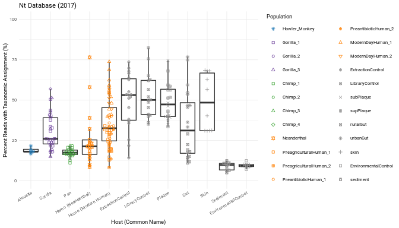

```r
final_nt_plot <- ggplot(metadata, aes(Host_Common, Percentage_Hits_with_Taxonomy)) +
  geom_boxplot(outlier.size = -1) +
  geom_beeswarm(aes(colour = Env, shape = Env), stroke = 0.4, size = 1.2) +
  scale_fill_brewer(palette = "Set1") +
  xlab("Host (Common Name)") +
  ylab("Percent Reads with Taxonomic Assignment (%)") +
  scale_shape_manual(values = env_shapes, name = "Population") +
  labs(title = "Nt Database (2017)") +
  scale_colour_manual(values = env_colours, "Population") +
  ylim(0, 100) +
  theme_minimal(base_size = 7, base_family = "Roboto") +
  theme(axis.text.x = element_text(angle = 30, hjust = 1))

final_nt_plot
```

For Refseq

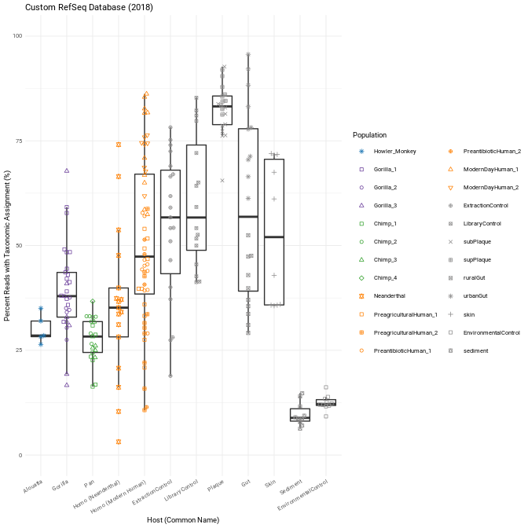

```r
final_refseq_plot <- ggplot(data_refseq_clean, aes(Host_Common, RefSeq_Percentage_Hits_with_Taxonomy)) +
  geom_boxplot(outlier.size = -1) +
  geom_beeswarm(aes(colour = Env, shape = Env), stroke = 0.4, size = 1.2) +
  scale_fill_brewer(palette = "Set1") +
  xlab("Host (Common Name)") +
  ylab("Percent Reads with Taxonomic Assignment (%)") +
  scale_shape_manual(values = env_shapes, name = "Population") +
  scale_colour_manual(values =env_colours, "Population") +
  labs(title = "Custom RefSeq Database (2018)") +
  ylim(0, 100) +
  theme_minimal(base_size = 7, base_family = "Roboto") +
  theme(axis.text.x = element_text(angle = 30, hjust = 1))

final_refseq_plot
```

```r
final_comparison_all <- final_nt_plot + final_refseq_plot + plot_layout(ncol = 1)

final_comparison_all

ggsave(paste0("SupFigX_MALTAssignments_AllCategories_comparison_" ,
             format(Sys.Date(), "%Y%m%d"),".pdf"),
       plot = final_comparison_all,
       path = "../04-analysis/screening/malt",
       device = cairo_pdf,
       width = 7,
       height = 5,
       units = "in",
       dpi = 600)
```

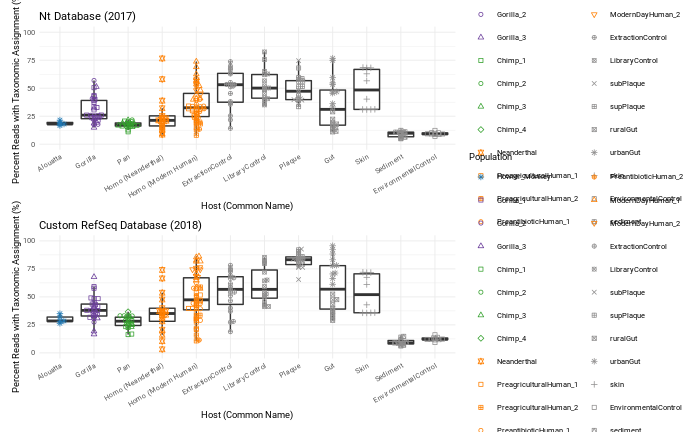

```r
ggsave(paste0("SupFigX_MALTAssignments_AllCategories_comparison_" ,
             format(Sys.Date(), "%Y%m%d"),".png"),
       plot = final_comparison_all,
       path = "../04-analysis/screening/malt",
       device = "png",
       width = 7,
       height = 5,
       units = "in",
       dpi = 600)
```

## Database comparison percent taxonomically assigned

Comparison across databases

[figure not shown]

We can see that there appears to be an increase in the mean percentage of reads with taxonomic assignment. If we want to statistically test the confidence of the increase, we can use the recently released `dabestr` package which aims to move away from simple yes/no *p*-value descisions but move towards estimation statistics - i.e. visualise the confidence of in the difference between the means of two populations via bootstrapping and confidence intervals (i.e. effect size) (Ho et al. 2019 Nat. Methods). Bootstrapping follows a non-parametric statistical framework which applies to our data here.

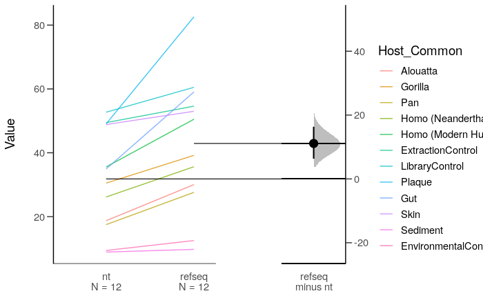

```r
dabest_res <- dabest(summary_bothdb %>% filter(Metric == "Mean"),
       Database,
       Value,
       idx = c("nt", "refseq"),
       paired = T,
       id.column = Host_Common)

dabest_all <- plot(dabest_res, color.column = Host_Common)

dabest_all
```

We can also check more specifically the calculus samples

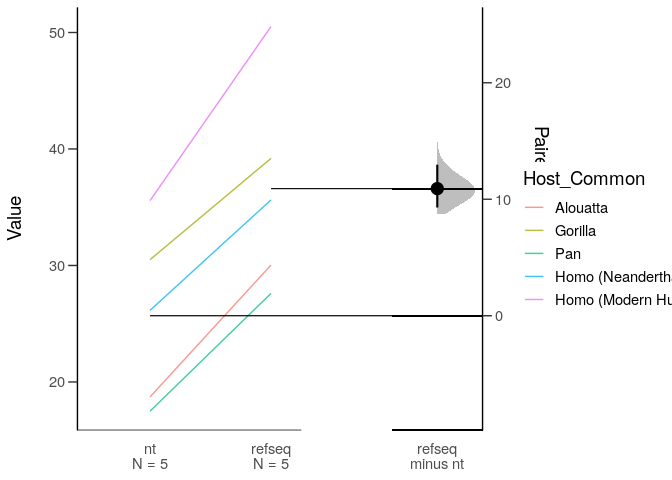

```r
dabest_res_calculusonly <- dabest(summary_bothdb %>% filter(Metric == "Mean",
                                               Host_Common %in% c("Alouatta",
                                                                  "Pan",
                                                                  "Gorilla",
                                                                  "Homo (Neanderthal)",
                                                                  "Homo (Modern Human)")),
       Database,
       Value,
       idx = c("nt", "refseq"),
       paired = T,
       id.column = Host_Common)


dabest_calculus <- plot(dabest_res_calculusonly, color.column = Host_Common)

dabest_calculus
```

Put together

> This will need to be fixed in postprocessing!

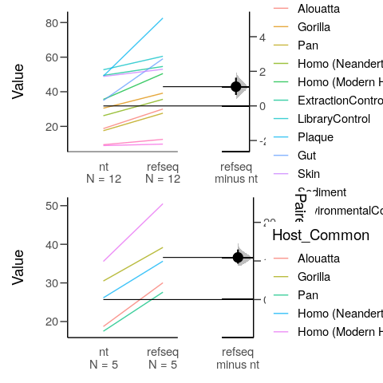

```r
dabest_final <- dabest_all + dabest_calculus + plot_layout(ncol = 1)

dabest_final
```

```r
ggsave(paste0("SupFigX_MALTAssignments_dabest_AllCategoriesCalculusOnly_comparison_" ,
             format(Sys.Date(), "%Y%m%d"),".pdf"),
       plot = dabest_final,
       path = "../04-analysis/screening/malt",
       device = cairo_pdf,
       width = 5,
       height = 5,
       units = "in",
       dpi = 600)

ggsave(paste0("SupFigX_MALTAssignments_dabest_AllCategoriesCalculusOnly_comparison_" ,
             format(Sys.Date(), "%Y%m%d"),".png"),
       plot = dabest_final,
       path = "../04-analysis/screening/malt",
       device = "png",
       width = 5,
       height = 5,
       units = "in",
       dpi = 600)
```

In both cases we see a clear difference in the paired means

## Calculus only percent taxnonmoically assigned

For nt but only modern humans

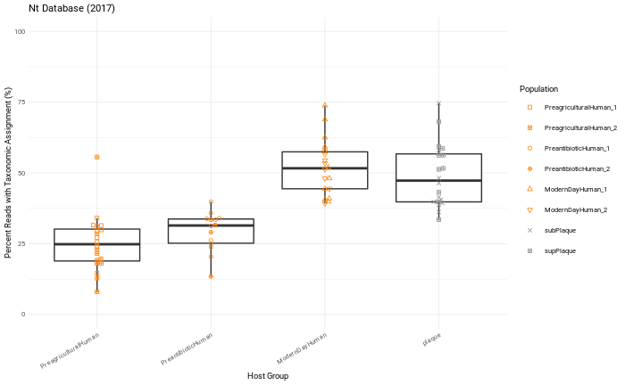

```r
modernhumanoral_nt <- ggplot(data_modernhumanoral_nt, aes(Host_General, Percentage_Hits_with_Taxonomy)) +
  geom_boxplot(outlier.size = -1) +
  geom_beeswarm(aes(colour = Env, shape = Env), stroke = 0.4, size = 1.2) +
  scale_fill_brewer(palette = "Set1") +
  xlab("Host Group") +
  ylab("Percent Reads with Taxonomic Assignment (%)") +
  scale_shape_manual(values = env_shapes, name = "Population") +
  scale_colour_manual(values = env_colours, "Population") +
  labs(title = "Nt Database (2017)") +
  ylim(0, 100) +
  theme_minimal(base_size = 7, base_family = "Roboto") +
  theme(axis.text.x = element_text(angle = 30, hjust = 1))

modernhumanoral_nt
```

For refseq but only modern humans

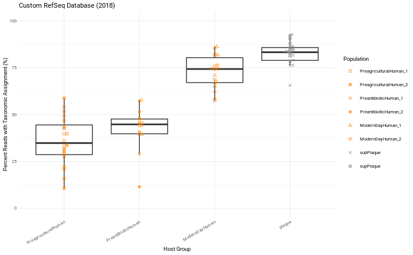

```r
modernhumanoral_refseq <- ggplot(data_modernhumanoral_refseq, aes(Host_General, RefSeq_Percentage_Hits_with_Taxonomy)) +
  geom_boxplot(outlier.size = -1) +
  geom_beeswarm(aes(colour = Env, shape = Env), stroke = 0.4, size = 1.2) +
  scale_fill_brewer(palette = "Set1") +
  xlab("Host Group") +
  ylab("Percent Reads with Taxonomic Assignment (%)") +
  scale_shape_manual(values = env_shapes, name = "Population") +
  scale_colour_manual(values = env_colours, "Population") +
  labs(title = "Custom RefSeq Database (2018)") +
  ylim(0, 100) +
  theme_minimal(base_size = 7, base_family = "Roboto") +
  theme(axis.text.x = element_text(angle = 30, hjust = 1))

modernhumanoral_refseq
```

And together

```r
calculusonly_comparison <- modernhumanoral_nt + theme(legend.position = "none") + modernhumanoral_refseq + ylab("")
```

And save

```r
ggsave(paste0("SupFigX_MALTAssignments_CalculusPlaqueOnly_comparison_" ,
             format(Sys.Date(), "%Y%m%d"),".pdf"),
       plot = calculusonly_comparison,
       path = "../04-analysis/screening/malt",
       device = cairo_pdf,
       width = 7,
       height = 3,
       units = "in",
       dpi = 600)

ggsave(paste0("SupFigX_MALTAssignments_CalculusPlaqueOnly_comparison_" ,
             format(Sys.Date(), "%Y%m%d"),".png"),
       plot = calculusonly_comparison,
       path = "../04-analysis/screening/malt",
       device = "png",
       width = 7,
       height = 3,
       units = "in",
       dpi = 600)
```

## Eukaryotic vs non-Eukaryotic Ratio

To plot boxplots of ratios of eukaryotic vs non-eukaryotic alignments

```r
eukvsnoneuk_all_plot <- ggplot(data_megan_nt_domain_ratios, aes(Host_Common, Ratio)) +
  geom_violin(draw_quantiles = c(0.25, 0.5, 0.75)) +
  geom_beeswarm(aes(colour = Env, shape = Env), stroke = 0.4, size = 1.2) +
  scale_fill_brewer(palette = "Set1") +
  xlab("Host (Common Name)") +
  ylab("Ratio Bacterial/Archaeal/Viral Reads over Eukaryotic") +
  scale_shape_manual(values = env_shapes, name = "Population") +
  scale_colour_manual(values = env_colours, "Population") +
  scale_y_log10() +
  theme_minimal(base_size = 7, base_family = "Roboto") +
  theme(axis.text.x = element_text(angle = 30, hjust = 1))

eukvsnoneuk_all_plot

ggsave(paste0("SupFigX_MALTAssignments_all_eukaryoticNoneukaryoticRatio_" ,
             format(Sys.Date(), "%Y%m%d"),".pdf"),
       plot = eukvsnoneuk_all_plot,
       path = "../04-analysis/screening/malt",
       device = cairo_pdf,
       width = 7,
       height = 3,
       units = "in",
       dpi = 600)
```

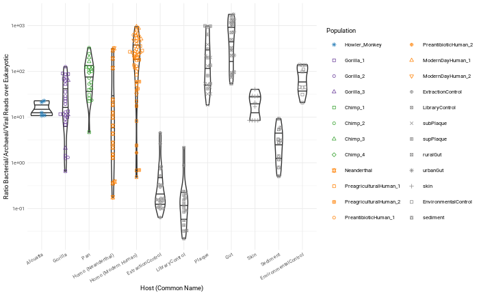

```r
ggsave(paste0("SupFigX_MALTAssignments_all_eukaryoticNoneukaryoticRatio_" ,
             format(Sys.Date(), "%Y%m%d"),".png"),
       plot = eukvsnoneuk_all_plot,
       path = "../04-analysis/screening/malt",
       device = "png",
       width = 7,
       height = 3,
       units = "in",
       dpi = 600)
```

```r
eukvsnoneuk_modernhumanplaque_plot <- ggplot(data_megan_nt_domain_ratios_modernhumanonly, aes(Host_General, Ratio)) +
  geom_violin(draw_quantiles = c(0.25, 0.5, 0.75)) +
  geom_beeswarm(aes(colour = Env, shape = Env), stroke = 0.4, size = 1.2) +
  scale_fill_brewer(palette = "Set1") +
  xlab("Host Group") +
  ylab("Ratio Bacterial/Archaeal/Viral Reads over Eukaryotic") +
  scale_shape_manual(values = env_shapes, name = "Population") +
  scale_colour_manual(values = env_colours, "Population") +
  theme_minimal(base_size = 7, base_family = "Roboto") +
  theme(axis.text.x = element_text(angle = 30, hjust = 1))

eukvsnoneuk_modernhumanplaque_plot

ggsave(paste0("SupFigX_MALTAssignments_CalculusPlaqueOnly_eukaryoticNoneukaryoticRatio_" ,
             format(Sys.Date(), "%Y%m%d"),".pdf"),
       plot = eukvsnoneuk_modernhumanplaque_plot,
       path = "../04-analysis/screening/malt",
       device = cairo_pdf,
       width = 7,
       height = 3,
       units = "in",
       dpi = 600)
```

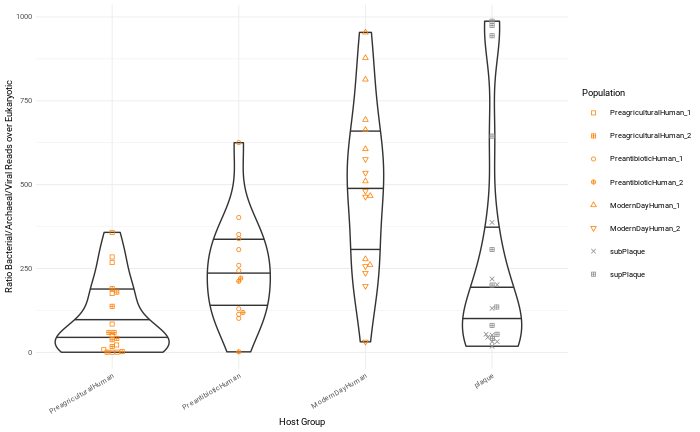

```r
ggsave(paste0("SupFigX_MALTAssignments_CalculusPlaqueOnly_eukaryoticNoneukaryoticRatio_" ,
             format(Sys.Date(), "%Y%m%d"),".png"),
       plot = eukvsnoneuk_modernhumanplaque_plot,
       path = "../04-analysis/screening/malt",
       device = "png",
       width = 7,
       height = 3,
       units = "in",
       dpi = 600)
```